# Churn Rate Prediction of E-Commerce Customer

***A personal project by Azizha Zeinita***

- **Project Goal:** The purpose of this project is to find **customer churn rate prediction in e-commerce** dataset. This approach is used to detect which features affect churn rate, so that company can use it to do future forecasting to **predict which customers who tend to leave the service** and make **promotion strategy** to offer.
- **Dataset:**
  - The data set belongs to a leading online E-Commerce company that's posted in https://www.kaggle.com/code/wonderdavid/e-commerce-customer-churn-prediction/data
  - Dataset is splitted to train, validation, and test
- **Methods:** Using GridSearchCV 5 folds for 6 kind of models with different kind of parameters:
  - Linear Classifier
    - Logistic Regression
    - Naive Bayes
    - SVM
  - Tree Classifier:
    - DecisionTreeClassifier
    - RandomForestClassifier
    - XGBClassifier

```python
import pandas as pd
import numpy as np
import seaborn as sns
import matplotlib.pyplot as plt
import warnings
warnings.filterwarnings('ignore')
import os
os.getcwd()
```

```
'/Users/azizhazeinita/Project/Churn Rate'
```

```python
# Check dataset dictionary
dicti = pd.read_excel('/Users/azizhazeinita/Project/Churn Rate/E Commerce Churn.xlsx', sheet_name='Data Dict', header=1, usecols=[2,3])
pd.set_option('max_colwidth',100)
dicti
```

|  | Variable | Discerption |
| --- | --- | --- |
| 0 | CustomerID | Unique customer ID |
| 1 | Churn | Churn Flag |
| 2 | Tenure | Tenure of customer in organization |
| 3 | PreferredLoginDevice | Preferred login device of customer |
| 4 | CityTier | City tier |
| 5 | WarehouseToHome | Distance in between warehouse to home of customer |
| 6 | PreferredPaymentMode | Preferred payment method of customer |
| 7 | Gender | Gender of customer |
| 8 | HourSpendOnApp | Number of hours spend on mobile application or website |
| 9 | NumberOfDeviceRegistered | Total number of deceives is registered on particular customer |
| 10 | PreferedOrderCat | Preferred order category of customer in last month |
| 11 | SatisfactionScore | Satisfactory score of customer on service |
| 12 | MaritalStatus | Marital status of customer |
| 13 | NumberOfAddress | Total number of added added on particular customer |
| 14 | Complain | Any complaint has been raised in last month |
| 15 | OrderAmountHikeFromlastYear | Percentage increases in order from last year |
| 16 | CouponUsed | Total number of coupon has been used in last month |
| 17 | OrderCount | Total number of orders has been places in last month |
| 18 | DaySinceLastOrder | Day Since last order by customer |
| 19 | CashbackAmount | Average cashback in last month |

```python
# Load Dataset
df = pd.read_excel('/Users/azizhazeinita/Project/Churn Rate/E Commerce Churn.xlsx', sheet_name='E Comm')
df.head()
```

|  | CustomerID | Churn | Tenure | PreferredLoginDevice | CityTier | WarehouseToHome | PreferredPaymentMode | Gender | HourSpendOnApp | NumberOfDeviceRegistered | PreferedOrderCat | SatisfactionScore | MaritalStatus | NumberOfAddress | Complain | OrderAmountHikeFromlastYear | CouponUsed | OrderCount | DaySinceLastOrder | CashbackAmount |
| --- | --- | --- | --- | --- | --- | --- | --- | --- | --- | --- | --- | --- | --- | --- | --- | --- | --- | --- | --- | --- |
| 0 | 50001 | 1 | 4.0 | Mobile Phone | 3 | 6.0 | Debit Card | Female | 3.0 | 3 | Laptop & Accessory | 2 | Single | 9 | 1 | 11.0 | 1.0 | 1.0 | 5.0 | 159.93 |
| 1 | 50002 | 1 | NaN | Phone | 1 | 8.0 | UPI | Male | 3.0 | 4 | Mobile | 3 | Single | 7 | 1 | 15.0 | 0.0 | 1.0 | 0.0 | 120.90 |
| 2 | 50003 | 1 | NaN | Phone | 1 | 30.0 | Debit Card | Male | 2.0 | 4 | Mobile | 3 | Single | 6 | 1 | 14.0 | 0.0 | 1.0 | 3.0 | 120.28 |
| 3 | 50004 | 1 | 0.0 | Phone | 3 | 15.0 | Debit Card | Male | 2.0 | 4 | Laptop & Accessory | 5 | Single | 8 | 0 | 23.0 | 0.0 | 1.0 | 3.0 | 134.07 |
| 4 | 50005 | 1 | 0.0 | Phone | 1 | 12.0 | CC | Male | NaN | 3 | Mobile | 5 | Single | 3 | 0 | 11.0 | 1.0 | 1.0 | 3.0 | 129.60 |

```python
df.tail()
```

|  | CustomerID | Churn | Tenure | PreferredLoginDevice | CityTier | WarehouseToHome | PreferredPaymentMode | Gender | HourSpendOnApp | NumberOfDeviceRegistered | PreferedOrderCat | SatisfactionScore | MaritalStatus | NumberOfAddress | Complain | OrderAmountHikeFromlastYear | CouponUsed | OrderCount | DaySinceLastOrder | CashbackAmount |
| --- | --- | --- | --- | --- | --- | --- | --- | --- | --- | --- | --- | --- | --- | --- | --- | --- | --- | --- | --- | --- |
| 5625 | 55626 | 0 | 10.0 | Computer | 1 | 30.0 | Credit Card | Male | 3.0 | 2 | Laptop & Accessory | 1 | Married | 6 | 0 | 18.0 | 1.0 | 2.0 | 4.0 | 150.71 |
| 5626 | 55627 | 0 | 13.0 | Mobile Phone | 1 | 13.0 | Credit Card | Male | 3.0 | 5 | Fashion | 5 | Married | 6 | 0 | 16.0 | 1.0 | 2.0 | NaN | 224.91 |
| 5627 | 55628 | 0 | 1.0 | Mobile Phone | 1 | 11.0 | Debit Card | Male | 3.0 | 2 | Laptop & Accessory | 4 | Married | 3 | 1 | 21.0 | 1.0 | 2.0 | 4.0 | 186.42 |
| 5628 | 55629 | 0 | 23.0 | Computer | 3 | 9.0 | Credit Card | Male | 4.0 | 5 | Laptop & Accessory | 4 | Married | 4 | 0 | 15.0 | 2.0 | 2.0 | 9.0 | 178.90 |
| 5629 | 55630 | 0 | 8.0 | Mobile Phone | 1 | 15.0 | Credit Card | Male | 3.0 | 2 | Laptop & Accessory | 3 | Married | 4 | 0 | 13.0 | 2.0 | 2.0 | 3.0 | 169.04 |

### EDA - General

```python
# Get general information of each columns
df.info()
```

```
<class 'pandas.core.frame.DataFrame'>
RangeIndex: 5630 entries, 0 to 5629
Data columns (total 20 columns):
 #   Column                       Non-Null Count  Dtype
---  ------                       --------------  -----
 0   CustomerID                   5630 non-null   int64
 1   Churn                        5630 non-null   int64
 2   Tenure                       5366 non-null   float64
 3   PreferredLoginDevice         5630 non-null   object
 4   CityTier                     5630 non-null   int64
 5   WarehouseToHome              5379 non-null   float64
 6   PreferredPaymentMode         5630 non-null   object
 7   Gender                       5630 non-null   object
 8   HourSpendOnApp               5375 non-null   float64
 9   NumberOfDeviceRegistered     5630 non-null   int64
 10  PreferedOrderCat             5630 non-null   object
 11  SatisfactionScore            5630 non-null   int64
 12  MaritalStatus                5630 non-null   object
 13  NumberOfAddress              5630 non-null   int64
 14  Complain                     5630 non-null   int64
 15  OrderAmountHikeFromlastYear  5365 non-null   float64
 16  CouponUsed                   5374 non-null   float64
 17  OrderCount                   5372 non-null   float64
 18  DaySinceLastOrder            5323 non-null   float64
 19  CashbackAmount               5630 non-null   float64
dtypes: float64(8), int64(7), object(5)
memory usage: 879.8+ KB
```

- We have 20 columns and 5630 rows in the dataset with data types of int, float, and object. The number of non-null rows for each columns are not the same, which means there are null values in several columns

```python
# Check Percentage of Null Value in Each Column Compared to Total Rows of Data Frame

round((((df.isnull().sum())/len(df))*100), 2)
```

```
CustomerID                     0.00
Churn                          0.00
Tenure                         4.69
PreferredLoginDevice           0.00
CityTier                       0.00
WarehouseToHome                4.46
PreferredPaymentMode           0.00
Gender                         0.00
HourSpendOnApp                 4.53
NumberOfDeviceRegistered       0.00
PreferedOrderCat               0.00
SatisfactionScore              0.00
MaritalStatus                  0.00
NumberOfAddress                0.00
Complain                       0.00
OrderAmountHikeFromlastYear    4.71
CouponUsed                     4.55
OrderCount                     4.58
DaySinceLastOrder              5.45
CashbackAmount                 0.00
dtype: float64
```

- As assumed, seven columns have null values. Because the percentages of null values are all below 30%, it can be left as it is, but I'll fill those in with median value on the next part

```python
# Checking Stastical Description
df.describe()
```

|  | CustomerID | Churn | Tenure | CityTier | WarehouseToHome | HourSpendOnApp | NumberOfDeviceRegistered | SatisfactionScore | NumberOfAddress | Complain | OrderAmountHikeFromlastYear | CouponUsed | OrderCount | DaySinceLastOrder | CashbackAmount |
| --- | --- | --- | --- | --- | --- | --- | --- | --- | --- | --- | --- | --- | --- | --- | --- |
| count | 5630.000000 | 5630.000000 | 5366.000000 | 5630.000000 | 5379.000000 | 5375.000000 | 5630.000000 | 5630.000000 | 5630.000000 | 5630.000000 | 5365.000000 | 5374.000000 | 5372.000000 | 5323.000000 | 5630.000000 |
| mean | 52815.500000 | 0.168384 | 10.189899 | 1.654707 | 15.639896 | 2.931535 | 3.688988 | 3.066785 | 4.214032 | 0.284902 | 15.707922 | 1.751023 | 3.008004 | 4.543491 | 177.223030 |
| std | 1625.385339 | 0.374240 | 8.557241 | 0.915389 | 8.531475 | 0.721926 | 1.023999 | 1.380194 | 2.583586 | 0.451408 | 3.675485 | 1.894621 | 2.939680 | 3.654433 | 49.207036 |
| min | 50001.000000 | 0.000000 | 0.000000 | 1.000000 | 5.000000 | 0.000000 | 1.000000 | 1.000000 | 1.000000 | 0.000000 | 11.000000 | 0.000000 | 1.000000 | 0.000000 | 0.000000 |
| 25% | 51408.250000 | 0.000000 | 2.000000 | 1.000000 | 9.000000 | 2.000000 | 3.000000 | 2.000000 | 2.000000 | 0.000000 | 13.000000 | 1.000000 | 1.000000 | 2.000000 | 145.770000 |
| 50% | 52815.500000 | 0.000000 | 9.000000 | 1.000000 | 14.000000 | 3.000000 | 4.000000 | 3.000000 | 3.000000 | 0.000000 | 15.000000 | 1.000000 | 2.000000 | 3.000000 | 163.280000 |
| 75% | 54222.750000 | 0.000000 | 16.000000 | 3.000000 | 20.000000 | 3.000000 | 4.000000 | 4.000000 | 6.000000 | 1.000000 | 18.000000 | 2.000000 | 3.000000 | 7.000000 | 196.392500 |
| max | 55630.000000 | 1.000000 | 61.000000 | 3.000000 | 127.000000 | 5.000000 | 6.000000 | 5.000000 | 22.000000 | 1.000000 | 26.000000 | 16.000000 | 16.000000 | 46.000000 | 324.990000 |

- Some columns have standard deviation value more than 2, which is considered as high. We need to check the outlier of the data
- Since CustomerID has extremely high minimum value and not really needed, I'll take it out from dataframe

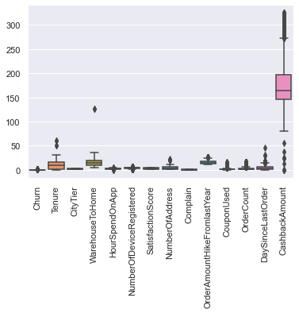

```python
# Checking outliers with boxplot

# Dropping CustomerID
df = df.drop('CustomerID', axis=1)

# Visualizing IQR to see outliers
sns.boxplot(data=df)
plt.xticks(rotation=90)
plt.show()
```

```python
# Checking skewness
df.skew()
```

```
Churn                          1.772843
Tenure                         0.736513
CityTier                       0.735326
WarehouseToHome                1.619154
HourSpendOnApp                -0.027213
NumberOfDeviceRegistered      -0.396969
SatisfactionScore             -0.142626
NumberOfAddress                1.088639
Complain                       0.953347
OrderAmountHikeFromlastYear    0.790785
CouponUsed                     2.545653
OrderCount                     2.196414
DaySinceLastOrder              1.191000
CashbackAmount                 1.149846
dtype: float64
```

- Although skewness values are less than |3|, there are many outliers that need to be handled in the next stage

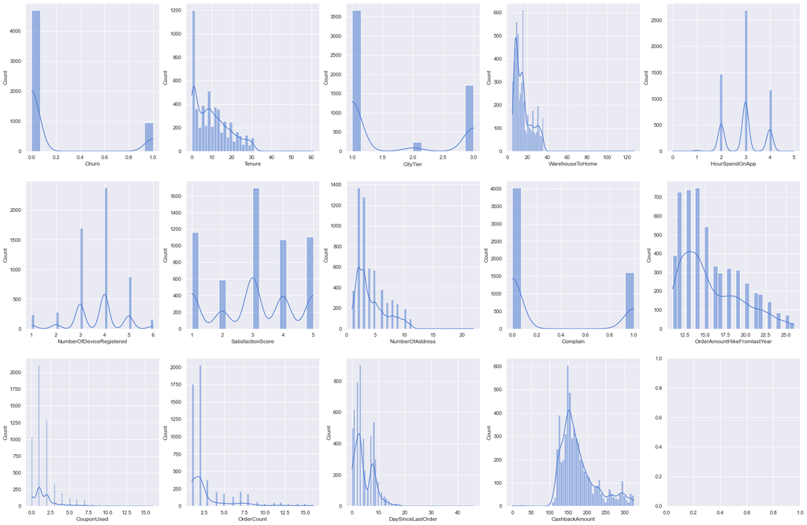

```python
# Selecting numerical columns only
col = df.select_dtypes(exclude='object').columns

# Vusualizing Distribution of Each Numerical Columns
fig,ax = plt.subplots(3, 5, figsize=(30, 20))
for i, subplot in zip(col, ax.flatten()):
    sns.histplot(df[i], kde = True, ax=subplot)
```

- Not even one of them is normal distribution, mostly skewed and multimodal
- Some of those numerical columns are **categorical**, such as Churn, CityTier, and Complain

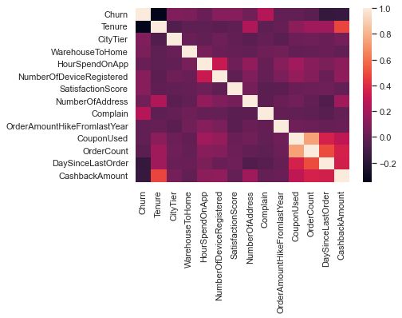

```python
# Visualizing Pearson's correlation between features
sns.heatmap(df.corr())
```

### EDA - Target Variable

- Target Variable: Churn

```python
# Checking Pearson's correlation between target variable (Churn) and features
df.corr()['Churn']
```

```
Churn                          1.000000
Tenure                        -0.349408
CityTier                       0.084703
WarehouseToHome                0.076630
HourSpendOnApp                 0.018675
NumberOfDeviceRegistered       0.107939
SatisfactionScore              0.105481
NumberOfAddress                0.043931
Complain                       0.250188
OrderAmountHikeFromlastYear   -0.010058
CouponUsed                    -0.008264
OrderCount                    -0.028697
DaySinceLastOrder             -0.160757
CashbackAmount                -0.154118
Name: Churn, dtype: float64
```

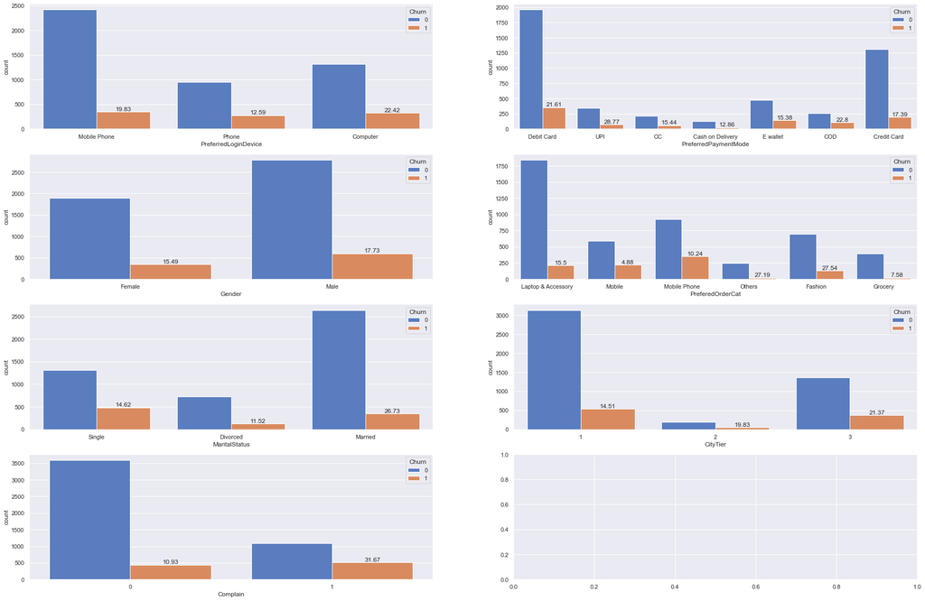

```python
# Selecting categorical columns only
col_cat = df.select_dtypes(include='object')

# Add numerical columns that have functionality as categorical columns
col_cat['CityTier'] = df['CityTier']
col_cat['Complain'] = df['Complain']

# Get columns name
col_cat_name = col_cat.columns

# Showing how churn rate distribution in each categorical values in each columns
fig,ax = plt.subplots(4, 2, figsize=(30, 20))
for col,subplot in zip(col_cat, ax.flatten()):

    # Counting churn rate: churn values compared to total values in each categories
    churn = df.groupby(by=df[col]).Churn.sum()
    total = df.value_counts(col).sort_index()
    percent = round((churn/total*100),2)

    # Showing countplot
    a = sns.countplot(x = df[col], hue=df.Churn, ax=subplot)

    # Giving labels of churn rate
    a.bar_label(container=a.containers[1], labels=percent)
```

- Most categories have churn rate above 10% with the highest rate of 31.67%, and only two catories have low churn rate of 4.88% (Mobile) and 7.58% (Grocery) in column PreferedOrderCat

### Feature Engineering

#### 1. Handling Missing Values

- Fill null values with median instead of mean, which is better for skewed data

```python
# Fill null values in some columns with median

df['Tenure'].fillna(df['Tenure'].median(), inplace=True)
df['WarehouseToHome'].fillna(df['WarehouseToHome'].median(), inplace=True)
df['HourSpendOnApp'].fillna(df['HourSpendOnApp'].median(), inplace=True)
df['OrderAmountHikeFromlastYear'].fillna(df['OrderAmountHikeFromlastYear'].median(), inplace=True)
df['CouponUsed'].fillna(df['CouponUsed'].median(), inplace=True)
df['OrderCount'].fillna(df['OrderCount'].median(), inplace=True)
df['DaySinceLastOrder'].fillna(df['DaySinceLastOrder'].median(), inplace=True)

# Checking number of null value
round((((df.isnull().sum())/len(df))*100), 2)
```

```
Churn                          0.0
Tenure                         0.0
PreferredLoginDevice           0.0
CityTier                       0.0
WarehouseToHome                0.0
PreferredPaymentMode           0.0
Gender                         0.0
HourSpendOnApp                 0.0
NumberOfDeviceRegistered       0.0
PreferedOrderCat               0.0
SatisfactionScore              0.0
MaritalStatus                  0.0
NumberOfAddress                0.0
Complain                       0.0
OrderAmountHikeFromlastYear    0.0
CouponUsed                     0.0
OrderCount                     0.0
DaySinceLastOrder              0.0
CashbackAmount                 0.0
dtype: float64
```

- There are no null values shown in the dataset anymore

#### 2. Handling Outliers

```python
# Select only numerical values, except Churn
numeric = df.select_dtypes(exclude='object').drop('Churn',axis=1)
numeric.head()
```

|  | Tenure | CityTier | WarehouseToHome | HourSpendOnApp | NumberOfDeviceRegistered | SatisfactionScore | NumberOfAddress | Complain | OrderAmountHikeFromlastYear | CouponUsed | OrderCount | DaySinceLastOrder | CashbackAmount |
| --- | --- | --- | --- | --- | --- | --- | --- | --- | --- | --- | --- | --- | --- |
| 0 | 4.0 | 3 | 6.0 | 3.0 | 3 | 2 | 9 | 1 | 11.0 | 1.0 | 1.0 | 5.0 | 159.93 |
| 1 | 9.0 | 1 | 8.0 | 3.0 | 4 | 3 | 7 | 1 | 15.0 | 0.0 | 1.0 | 0.0 | 120.90 |
| 2 | 9.0 | 1 | 30.0 | 2.0 | 4 | 3 | 6 | 1 | 14.0 | 0.0 | 1.0 | 3.0 | 120.28 |
| 3 | 0.0 | 3 | 15.0 | 2.0 | 4 | 5 | 8 | 0 | 23.0 | 0.0 | 1.0 | 3.0 | 134.07 |
| 4 | 0.0 | 1 | 12.0 | 3.0 | 3 | 5 | 3 | 0 | 11.0 | 1.0 | 1.0 | 3.0 | 129.60 |

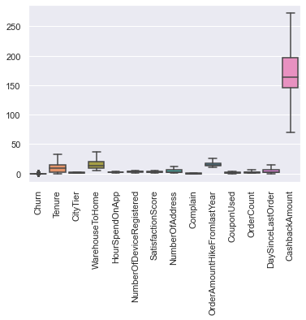

```
Churn                          1.772843
Tenure                         0.692039
CityTier                       0.735326
WarehouseToHome                0.944524
HourSpendOnApp                -0.032308
NumberOfDeviceRegistered      -0.303717
SatisfactionScore             -0.142626
NumberOfAddress                0.965972
Complain                       0.953347
OrderAmountHikeFromlastYear    0.824247
CouponUsed                     0.532024
OrderCount                     1.148036
DaySinceLastOrder              0.818655
CashbackAmount                 0.903849
dtype: float64
```

```python
# Handling outlier with IQR method
for column in numeric.columns:

    # Set up Q1, Q2, and Q3
    Q1 = df[column].quantile(0.25)
    Q3 = df[column].quantile(0.75)
    IQR = Q3-Q1

    # Set up upper range and lower range
    upper = Q3 + (1.5*IQR)
    lower = Q1 - (1.5*IQR)

    # Outliers are df.CRIM < lower OR df.CRIM > upper
    # So, I'll only take data >lower and <upper (capping)
    df[column] = np.where(df[column] < lower, lower, np.where(df[column] > upper, upper, df[column]))
    df[column] = pd.DataFrame(df[column])

# Visualizing IQR to see the result after handling outlier
sns.boxplot(data=df)
plt.xticks(rotation=90)
plt.show()

# Checking skewness
df.skew()
```

#### 3. Turn Categorical Variables with Object Datatype to be Numerical

```python
# Turn them using LabelEncoder, so we don't need to have to many columns like produced by get_dummies
from sklearn.preprocessing import LabelEncoder
le = LabelEncoder()

for i in df.select_dtypes(include='object'):
    df[i] = le.fit_transform(df[i])

df.head()
```

|  | Churn | Tenure | PreferredLoginDevice | CityTier | WarehouseToHome | PreferredPaymentMode | Gender | HourSpendOnApp | NumberOfDeviceRegistered | PreferedOrderCat | SatisfactionScore | MaritalStatus | NumberOfAddress | Complain | OrderAmountHikeFromlastYear | CouponUsed | OrderCount | DaySinceLastOrder | CashbackAmount |
| --- | --- | --- | --- | --- | --- | --- | --- | --- | --- | --- | --- | --- | --- | --- | --- | --- | --- | --- | --- |
| 0 | 1 | 4.0 | 1 | 3.0 | 6.0 | 4 | 0 | 3.0 | 3.0 | 2 | 2.0 | 2 | 9.0 | 1.0 | 11.0 | 1.0 | 1.0 | 5.0 | 159.93 |
| 1 | 1 | 9.0 | 2 | 1.0 | 8.0 | 6 | 1 | 3.0 | 4.0 | 3 | 3.0 | 2 | 7.0 | 1.0 | 15.0 | 0.0 | 1.0 | 0.0 | 120.90 |
| 2 | 1 | 9.0 | 2 | 1.0 | 30.0 | 4 | 1 | 2.0 | 4.0 | 3 | 3.0 | 2 | 6.0 | 1.0 | 14.0 | 0.0 | 1.0 | 3.0 | 120.28 |
| 3 | 1 | 0.0 | 2 | 3.0 | 15.0 | 4 | 1 | 2.0 | 4.0 | 2 | 5.0 | 2 | 8.0 | 0.0 | 23.0 | 0.0 | 1.0 | 3.0 | 134.07 |
| 4 | 1 | 0.0 | 2 | 1.0 | 12.0 | 0 | 1 | 3.0 | 3.0 | 3 | 5.0 | 2 | 3.0 | 0.0 | 11.0 | 1.0 | 1.0 | 3.0 | 129.60 |

#### 4. Preparing for Target and Features

```python
# Set up X and y
y = df.Churn
X = df.drop(['Churn'], axis=1)
```

### Modelling

- **Data Split**
1. Train (Splitted into train and validation via GridSearchCV)
2. Validation (Part of initial splitted train dataset via GridSearchCV)
3. Test
- **Linear Classifier**:
1. Logistic Regression
2. Naive Bayes
3. SVM
- **Tree Classifier**:
1. DecisionTreeClassifier
2. RandomForestClassifier
3. XGBClassifier

```python
# Import all libraries
from sklearn.model_selection import train_test_split, GridSearchCV
from sklearn.preprocessing import MinMaxScaler, StandardScaler
from sklearn.pipeline import Pipeline
from sklearn.base import BaseEstimator

from sklearn.linear_model import LogisticRegression
from sklearn.naive_bayes import GaussianNB
from sklearn.svm import LinearSVC
from sklearn.tree import DecisionTreeClassifier
from sklearn.ensemble import RandomForestClassifier
from xgboost import XGBClassifier

from sklearn.metrics import confusion_matrix, f1_score, accuracy_score, recall_score, precision_score
```

```python
# Split Data into Train and TEst
X_train, X_test, y_train, y_test = train_test_split(X, y, test_size=0.2)
print(X_train.shape, X_test.shape, y_train.shape, y_test.shape)
```

```
(4504, 18) (1126, 18) (4504,) (1126,)
```

```python
# Make Estimator Class
class cls_classifier(BaseEstimator,):
    def __init__(self, estimator=None):
        self.estimator = estimator
    def fit(self, X, y=None):
        self.estimator.fit(X,y)
        return self
    def predict(self, X, y=None):
        return self.estimator.predict(X,y)
    def predict_proba(self, X):
        return self.estimator.predict_proba(X)
    def score(self, X, y):
        return self.estimator.score(X, y)
```

```python
# Make Pipeline
pipeline = Pipeline([('scaler', MinMaxScaler()), ('clf', cls_classifier())])
# pipeline = Pipeline([('scaler', StandardScaler), ('clf', cls_classifier())])
```

```python
# Hyperparameter Tuning
param = [
    {
        'clf': [LogisticRegression()],
        'clf__solver': ['newton-cg', 'lbfgs', 'liblinear', 'sag', 'saga'],
        'clf__C' : np.logspace(-2, 2, 10)
    },
    {
        'clf': [GaussianNB()],
        'clf__var_smoothing': np.logspace(0,-9, num=100)
    },
    {
        'clf': [LinearSVC()],
        'clf__C': [0.1, 1, 10, 100, 1000]
    },
    {
        'clf': [RandomForestClassifier()],
        'clf__criterion':['gini','entropy'],
    },
    {
        'clf': [DecisionTreeClassifier()],
        'clf__criterion':['gini','entropy'],
    },
    {
        'clf': [XGBClassifier()],
        'clf__learning_rate':[0.01,0.1,0.2,0.3],
        'clf__reg_lambda':[0.01,0.1,1],
        'clf__reg_alpha': [0.01,0.1,0,1],
    }
]
```

```python
# Set Up GridSearchCV
gridsearch = GridSearchCV(pipeline, param, cv=5)
gridsearch.fit(X_train, y_train)
```

```
GridSearchCV(cv=5,
             estimator=Pipeline(steps=[('scaler', MinMaxScaler()),
                                       ('clf', cls_classifier())]),
             param_grid=[{'clf': [LogisticRegression()],
                          'clf__C': array([1.00000000e-02, 2.78255940e-02, 7.74263683e-02, 2.15443469e-01,
       5.99484250e-01, 1.66810054e+00, 4.64158883e+00, 1.29154967e+01,
       3.59381366e+01, 1.00000000e+02]),
                          'clf__solver': ['newton-cg', 'lbfgs', 'libline...
                                                max_cat_to_onehot=None,
                                                max_delta_step=None,
                                                max_depth=None, max_leaves=None,
                                                min_child_weight=None,
                                                missing=nan,
                                                monotone_constraints=None,
                                                n_estimators=100, n_jobs=None,
                                                num_parallel_tree=None,
                                                predictor=None,
                                                random_state=None,
                                                reg_alpha=0.1, reg_lambda=0.1, ...)],
                          'clf__learning_rate': [0.01, 0.1, 0.2, 0.3],
                          'clf__reg_alpha': [0.01, 0.1, 0, 1],
                          'clf__reg_lambda': [0.01, 0.1, 1]}])
```

### Evaluation

```python
# Get The Best Score
gridsearch.best_score_
```

```
0.9649209520286103
```

```python
# Show The Best Estimator (Model) That Has The Best Score
gridsearch.best_estimator_
```

```
Pipeline(steps=[('scaler', MinMaxScaler()),
                ('clf',
                 XGBClassifier(base_score=0.5, booster='gbtree', callbacks=None,
                               colsample_bylevel=1, colsample_bynode=1,
                               colsample_bytree=1, early_stopping_rounds=None,
                               enable_categorical=False, eval_metric=None,
                               gamma=0, gpu_id=-1, grow_policy='depthwise',
                               importance_type=None, interaction_constraints='',
                               learning_rate=0.3, max_bin=256,
                               max_cat_to_onehot=4, max_delta_step=0,
                               max_depth=6, max_leaves=0, min_child_weight=1,
                               missing=nan, monotone_constraints='()',
                               n_estimators=100, n_jobs=0, num_parallel_tree=1,
                               predictor='auto', random_state=0, reg_alpha=0.1,
                               reg_lambda=0.1, ...))])
```

```python
# Predict y In Test Dataset
y_pred = gridsearch.predict(X_test)

# Show Confussion Matrix
confusion_matrix(y_test, y_pred)
```

```
array([[930,   3],
       [ 14, 179]])
```

- The number of False Negative and False Positive are small, that's why the score is high

```python
# Show Accuracy Score
print('Accuracy: ', accuracy_score(y_test, y_pred))

# Show Precision Score
print('Precision: ', precision_score(y_test, y_pred))

# Show Recall Score
print('Recall: ', recall_score(y_test, y_pred))

# Show F1-Score
print('F1-Score: ', f1_score(y_test, y_pred))
```

```
Accuracy:  0.9849023090586145
Precision:  0.9835164835164835
Recall:  0.927461139896373
F1-Score:  0.9546666666666668
```

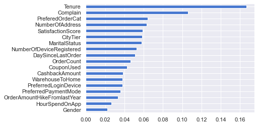

```python
# Finding Feature Importance

# Get coefficient of each features
fi = pd.Series(gridsearch.best_estimator_[-1].feature_importances_, index = X.columns)
fi.sort_values().plot(kind='barh')
```

### Summary

- The **best** model is **XGBClassifier** (parameters: learning_rate=0.3, reg_alpha=0.1, and reg_lambda=0.1) with the **mean score of accuracy is 0.964**, which is high enough. With this score, **the model is acceptable** to be applied by company to do forecasting on the new dataset and make strategy for promo offering
- The number of **true positive and true negative are really high** compared to false positive and false negative, which explains why accuracy, recall and F1 scores are also high
- **Tenure** and **Complain** features have the most significant role on the model, while other 16 features have less than 10% of importance